# F1 Optimal Pit Stop Predictor

## Development Plan

- **Phase 1**: Environment Setup & Data Acquisition
- **Phase 2**: Data Exploration & Feature Engineering
- **Phase 3**: Model Training & Evaluation with Neural Network
- **Phase 4**: Prediction Visualization

# Phase 1: Environment Setup & Data Acquisition

## Task 1.1: Environment Configuration

Setting up the required libraries and enabling F1 data caching.

```python
# Import core libraries
import fastf1 as ff1
import pandas as pd
import numpy as np
from datetime import datetime
import warnings
warnings.filterwarnings('ignore')

# Enable fastf1 cache to avoid re-downloading data
ff1.Cache.enable_cache('f1_cache')

print("✓ Environment setup complete!")
print(f"FastF1 version: {ff1.__version__}")
print(f"Pandas version: {pd.__version__}")
print(f"Numpy version: {np.__version__}")
```

```
✓ Environment setup complete!
FastF1 version: 3.5.3
Pandas version: 2.2.2
Numpy version: 1.26.0
```

```python
from tqdm import tqdm
import os

def get_race_data_for_year(year):
    """Download and process race data for a given year"""
    print(f"\n🏁 Processing {year} season...")

    # Get the race schedule for the year
    schedule = ff1.get_event_schedule(year)
    race_data = []

    for idx, event in tqdm(schedule.iterrows(), total=len(schedule), desc=f"{year} races"):
        try:
            # Skip non-race events (testing, sprints for now)
            if 'Grand Prix' not in event['EventName']:
                continue

            # Load the race session
            session = ff1.get_session(year, event['RoundNumber'], 'R')
            session.load()

            # Extract required data
            race_info = {
                'year': year,
                'round': event['RoundNumber'],
                'event_name': event['EventName'],
                'event_date': event['EventDate'],
                'laps_data': session.laps,
                'weather_data': session.weather_data,
                'session_status': session.laps[['LapNumber', 'TrackStatus']].drop_duplicates(),
                'total_laps': session.laps['LapNumber'].max()
            }

            race_data.append(race_info)
            print(f"  ✓ {event['EventName']} - {len(session.laps)} laps processed")

        except Exception as e:
            print(f"  ✗ Error processing {event['EventName']}: {str(e)}")
            continue

    return race_data

# Initialize data storage
all_race_data = {}

# Test with 2024 first (smaller dataset to validate approach)
print("Starting data collection...")
print("Note: This may take several minutes depending on your internet connection")

# Start with 2024 as test case
all_race_data[2024] = get_race_data_for_year(2024)

print(f"\n✓ Data collection complete!")
print(f"Collected data for {len(all_race_data[2024])} races in 2024")
```

```
Starting data collection...
Note: This may take several minutes depending on your internet connection

🏁 Processing 2024 season...
```

[output not shown]

```
  ✓ Bahrain Grand Prix - 1129 laps processed
```

[output not shown]

```
  ✓ Saudi Arabian Grand Prix - 901 laps processed
```

[output not shown]

```
  ✓ Australian Grand Prix - 998 laps processed
```

[output not shown]

```
  ✓ Japanese Grand Prix - 907 laps processed
```

[output not shown]

```
  ✓ Chinese Grand Prix - 1032 laps processed
```

[output not shown]

```
  ✓ Miami Grand Prix - 1111 laps processed
```

[output not shown]

```
  ✓ Emilia Romagna Grand Prix - 1238 laps processed
```

[output not shown]

```
  ✓ Monaco Grand Prix - 1237 laps processed
```

[output not shown]

```
  ✓ Canadian Grand Prix - 1272 laps processed
```

[output not shown]

```
  ✓ Spanish Grand Prix - 1310 laps processed
```

[output not shown]

[output cut: 21 more lines]

[output not shown]

```
  ✓ Austrian Grand Prix - 1405 laps processed
```

[output not shown]

```
  ✓ British Grand Prix - 961 laps processed
```

[output not shown]

```
  ✓ Hungarian Grand Prix - 1355 laps processed
```

[output not shown]

```
  ✓ Belgian Grand Prix - 841 laps processed
```

[output not shown]

```
  ✓ Dutch Grand Prix - 1426 laps processed
```

[output not shown]

```
  ✓ Italian Grand Prix - 1008 laps processed
```

[output not shown]

```
  ✓ Azerbaijan Grand Prix - 973 laps processed
```

[output not shown]

```
  ✓ Singapore Grand Prix - 1177 laps processed
```

[output not shown]

```
  ✓ United States Grand Prix - 1059 laps processed
```

[output not shown]

```
  ✓ Mexico City Grand Prix - 1215 laps processed
```

[output not shown]

```
  ✓ São Paulo Grand Prix - 1135 laps processed
```

[output not shown]

```
  ✓ Las Vegas Grand Prix - 938 laps processed
```

[output not shown]

[output cut: 10 more lines]

[output not shown]

```
  ✓ Qatar Grand Prix - 943 laps processed
```

[output not shown]

[output cut: 30 more lines]

[output not shown]

```
  ✓ Abu Dhabi Grand Prix - 1035 laps processed

✓ Data collection complete!
Collected data for 24 races in 2024
```

# Phase 2: Data Exploration & Feature Engineering

## Task 2.1: Data Consolidation

Merging lap data, pit stop information, and weather data into a structured DataFrame.

```python
def consolidate_race_data(race_info):
    """Consolidate a single race's data into a structured DataFrame"""

    # Get the basic lap data
    laps = race_info['laps_data'].copy()

    # Add pit stop information
    # Method 1: Use PitInTime or PitOutTime if available
    if 'PitInTime' in laps.columns:
        laps['IsPitStop'] = laps['PitInTime'].notna()
    elif 'PitOutTime' in laps.columns:
        laps['IsPitStop'] = laps['PitOutTime'].notna()
    else:
        # Method 2: Identify pit stops by analyzing stint and compound changes
        laps = laps.sort_values(['Driver', 'LapNumber']).reset_index(drop=True)
        laps['IsPitStop'] = False

        # Group by driver to analyze each driver separately
        for driver in laps['Driver'].unique():
            driver_mask = laps['Driver'] == driver
            driver_data = laps[driver_mask].copy()

            # Look for compound changes or significant stint changes
            compound_changes = (driver_data['Compound'] != driver_data['Compound'].shift()).fillna(False)
            stint_increases = (driver_data['Stint'] > driver_data['Stint'].shift()).fillna(False)

            # Mark pit stops where either compound changed or stint increased
            pit_laps = compound_changes | stint_increases
            laps.loc[driver_mask, 'IsPitStop'] = pit_laps.values

    print(f"  Identified {laps['IsPitStop'].sum()} pit stops")

    # Add track status information
    track_status = race_info['session_status']
    # Check if TrackStatus already exists to avoid duplicate columns
    if 'TrackStatus' in laps.columns:
        laps = laps.drop('TrackStatus', axis=1)
    laps = laps.merge(track_status, on='LapNumber', how='left')

    # Add weather data (sample to lap level)
    if not race_info['weather_data'].empty:
        weather = race_info['weather_data'].copy()
        weather['LapNumber'] = weather['Time'].dt.total_seconds() // 90  # Approximate lap duration
        weather_agg = weather.groupby('LapNumber').agg({
            'AirTemp': 'mean',
            'TrackTemp': 'mean',
            'Humidity': 'mean',
            'Pressure': 'mean',
            'WindSpeed': 'mean'
        }).reset_index()
        laps = laps.merge(weather_agg, on='LapNumber', how='left')

    # Add race metadata
    laps['Year'] = race_info['year']
    laps['Round'] = race_info['round']
    laps['EventName'] = race_info['event_name']
    laps['TotalLaps'] = race_info['total_laps']

    return laps

# Test with the first race from 2024
if all_race_data[2024]:
    sample_race = all_race_data[2024][0]
    sample_df = consolidate_race_data(sample_race)

    print(f"Sample race: {sample_race['event_name']}")
    print(f"DataFrame shape: {sample_df.shape}")
    print(f"Columns: {list(sample_df.columns)}")
    print(f"\nFirst few rows:")
    print(sample_df[['Driver', 'LapNumber', 'LapTime', 'Compound', 'IsPitStop']].head(10))
```

```
  Identified 43 pit stops
Sample race: Bahrain Grand Prix
DataFrame shape: (1189, 42)
Columns: ['Time', 'Driver', 'DriverNumber', 'LapTime', 'LapNumber', 'Stint', 'PitOutTime', 'PitInTime', 'Sector1Time', 'Sector2Time', 'Sector3Time', 'Sector1SessionTime', 'Sector2SessionTime', 'Sector3SessionTime', 'SpeedI1', 'SpeedI2', 'SpeedFL', 'SpeedST', 'IsPersonalBest', 'Compound', 'TyreLife',…

First few rows:
  Driver  LapNumber                LapTime Compound  IsPitStop
0    VER        1.0 0 days 00:01:37.284000     SOFT      False
1    VER        2.0 0 days 00:01:36.296000     SOFT      False
2    VER        3.0 0 days 00:01:36.753000     SOFT      False
3    VER        4.0 0 days 00:01:36.647000     SOFT      False
4    VER        5.0 0 days 00:01:37.173000     SOFT      False
5    VER        6.0 0 days 00:01:37.092000     SOFT      False
6    VER        7.0 0 days 00:01:37.038000     SOFT      False
7    VER        8.0 0 days 00:01:37.024000     SOFT      False
8    VER        9.0 0 days 00:01:37.229000     SOFT      False
9    VER        9.0 0 days 00:01:37.229000     SOFT      False
```

## Task 2.2: Exploratory Data Analysis (EDA)

Analyzing relationships between pit stops and various strategic factors.

```
📋 Available columns in sample_df:
['Time', 'Driver', 'DriverNumber', 'LapTime', 'LapNumber', 'Stint', 'PitOutTime', 'PitInTime', 'Sector1Time', 'Sector2Time', 'Sector3Time', 'Sector1SessionTime', 'Sector2SessionTime', 'Sector3SessionTime', 'SpeedI1', 'SpeedI2', 'SpeedFL', 'SpeedST', 'IsPersonalBest', 'Compound', 'TyreLife', 'FreshTy…

DataFrame shape: (1189, 42)
```

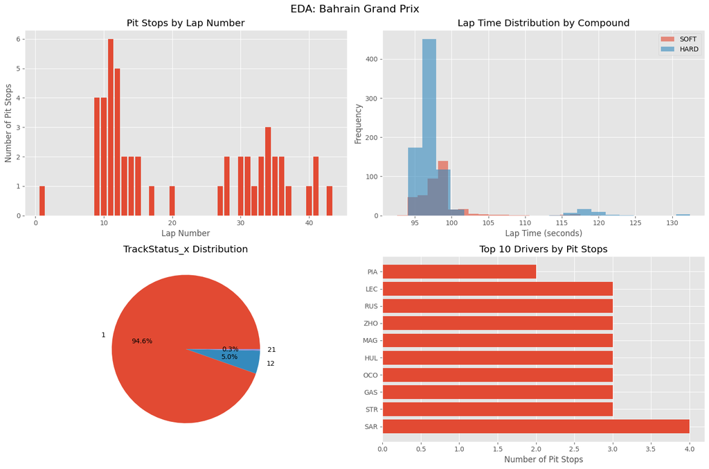

```
📊 Basic Statistics:
Total laps: 1189
Total pit stops: 50
Pit stop rate: 0.042
Unique drivers: 20
Unique compounds: 2
Compounds used: ['SOFT', 'HARD']
Weather data available: ['AirTemp', 'TrackTemp', 'Humidity', 'Pressure', 'WindSpeed']

🔍 Data Quality Check:
Lap time range: 92.6s - 132.4s
Track status values: ['12', '1', '21']
⚠️  Note: Found duplicate TrackStatus columns (merge conflict)
   TrackStatus_x has 3 unique values
   TrackStatus_y has 3 unique values

📝 Sample data (first 3 rows):
  Driver  LapNumber                LapTime Compound  IsPitStop  Position
0    VER        1.0 0 days 00:01:37.284000     SOFT      False       1.0
1    VER        2.0 0 days 00:01:36.296000     SOFT      False       1.0
2    VER        3.0 0 days 00:01:36.753000     SOFT      False       1.0
```

```python
# Import visualization libraries
import matplotlib.pyplot as plt
import seaborn as sns
plt.style.use('ggplot')

# Basic EDA on sample race data
if 'sample_df' in locals():

    # First, let's check what columns we actually have
    print("📋 Available columns in sample_df:")
    print(list(sample_df.columns))
    print(f"\nDataFrame shape: {sample_df.shape}")

    fig, axes = plt.subplots(2, 2, figsize=(15, 10))
    fig.suptitle(f'EDA: {sample_race["event_name"]}', fontsize=16)

    # 1. Pit stops by lap number
    if sample_df['IsPitStop'].sum() > 0:
        pit_stops_by_lap = sample_df[sample_df['IsPitStop']]['LapNumber'].value_counts().sort_index()
        axes[0,0].bar(pit_stops_by_lap.index, pit_stops_by_lap.values)
        axes[0,0].set_title('Pit Stops by Lap Number')
        axes[0,0].set_xlabel('Lap Number')
        axes[0,0].set_ylabel('Number of Pit Stops')
    else:
        axes[0,0].text(0.5, 0.5, 'No pit stops detected', ha='center', va='center', transform=axes[0,0].transAxes)
        axes[0,0].set_title('Pit Stops by Lap Number')

    # 2. Lap time distribution by compound
    if 'Compound' in sample_df.columns:
        compounds = sample_df['Compound'].dropna().unique()
        for compound in compounds:
            compound_data = sample_df[sample_df['Compound'] == compound]['LapTime'].dt.total_seconds()
            axes[0,1].hist(compound_data, alpha=0.6, label=compound, bins=20)
        axes[0,1].set_title('Lap Time Distribution by Compound')
        axes[0,1].set_xlabel('Lap Time (seconds)')
        axes[0,1].set_ylabel('Frequency')
        axes[0,1].legend()
    else:
        axes[0,1].text(0.5, 0.5, 'No Compound data available', ha='center', va='center', transform=axes[0,1].transAxes)
        axes[0,1].set_title('Lap Time Distribution by Compound')

    # 3. Track status analysis (check if column exists)
    track_status_col = None
    for col in ['TrackStatus', 'TrackStatus_x', 'TrackStatus_y', 'Status', 'SessionStatus']:
        if col in sample_df.columns:
            track_status_col = col
            break

    if track_status_col and sample_df[track_status_col].notna().sum() > 0:
        track_status_counts = sample_df[track_status_col].value_counts()
        axes[1,0].pie(track_status_counts.values, labels=track_status_counts.index, autopct='%1.1f%%')
        axes[1,0].set_title(f'{track_status_col} Distribution')
    else:
        axes[1,0].text(0.5, 0.5, 'No track status data available', ha='center', va='center', transform=axes[1,0].transAxes)
        axes[1,0].set_title('Track Status Distribution')

    # 4. Pit stop frequency by driver
    if sample_df['IsPitStop'].sum() > 0:
        pit_stops_by_driver = sample_df[sample_df['IsPitStop']]['Driver'].value_counts().head(10)
        if len(pit_stops_by_driver) > 0:
            axes[1,1].barh(pit_stops_by_driver.index, pit_stops_by_driver.values)
            axes[1,1].set_title('Top 10 Drivers by Pit Stops')
            axes[1,1].set_xlabel('Number of Pit Stops')
        else:
            axes[1,1].text(0.5, 0.5, 'No pit stop data', ha='center', va='center', transform=axes[1,1].transAxes)
            axes[1,1].set_title('Drivers by Pit Stops')
    else:
        axes[1,1].text(0.5, 0.5, 'No pit stops detected', ha='center', va='center', transform=axes[1,1].transAxes)
        axes[1,1].set_title('Drivers by Pit Stops')

    plt.tight_layout()
    plt.show()

    # Summary statistics
    print("\n📊 Basic Statistics:")
    print(f"Total laps: {len(sample_df)}")
    print(f"Total pit stops: {sample_df['IsPitStop'].sum()}")
    print(f"Pit stop rate: {sample_df['IsPitStop'].mean():.3f}")
    print(f"Unique drivers: {sample_df['Driver'].nunique()}")

    if 'Compound' in sample_df.columns:
        print(f"Unique compounds: {sample_df['Compound'].nunique()}")
        print(f"Compounds used: {list(sample_df['Compound'].dropna().unique())}")
    else:
        print("No compound information available")

    # Check if we have weather data
    weather_cols = ['AirTemp', 'TrackTemp', 'Humidity', 'Pressure', 'WindSpeed']
    available_weather = [col for col in weather_cols if col in sample_df.columns]
    if available_weather:
        print(f"Weather data available: {available_weather}")
    else:
        print("No weather data available")

    # Additional diagnostics
    print("\n🔍 Data Quality Check:")
    print(f"Lap time range: {sample_df['LapTime'].dt.total_seconds().min():.1f}s - {sample_df['LapTime'].dt.total_seconds().max():.1f}s")

    if track_status_col:
        print(f"Track status values: {list(sample_df[track_status_col].unique())}")

    if 'TrackStatus_x' in sample_df.columns and 'TrackStatus_y' in sample_df.columns:
        print("⚠️  Note: Found duplicate TrackStatus columns (merge conflict)")
        x_unique = sample_df['TrackStatus_x'].nunique()
        y_unique = sample_df['TrackStatus_y'].nunique()
        print(f"   TrackStatus_x has {x_unique} unique values")
        print(f"   TrackStatus_y has {y_unique} unique values")

    # Show a sample of the data
    print(f"\n📝 Sample data (first 3 rows):")
    display_cols = ['Driver', 'LapNumber', 'LapTime', 'Compound', 'IsPitStop', 'Position']
    available_display_cols = [col for col in display_cols if col in sample_df.columns]
    print(sample_df[available_display_cols].head(3).to_string())
```

## Task 2.3: Feature Creation

Engineering features based on domain knowledge and EDA insights.

```python
def create_features(df):
    """Create features for pit stop prediction using available F1 data columns"""

    df = df.copy()

    # Sort by driver and lap number for proper feature calculation
    df = df.sort_values(['Driver', 'LapNumber']).reset_index(drop=True)

    # Determine which TrackStatus column to use
    track_status_col = 'TrackStatus'
    if 'TrackStatus' not in df.columns:
        if 'TrackStatus_x' in df.columns:
            track_status_col = 'TrackStatus_x'
        elif 'TrackStatus_y' in df.columns:
            track_status_col = 'TrackStatus_y'

    # Feature engineering by driver
    features_list = []

    for driver in df['Driver'].unique():
        driver_data = df[df['Driver'] == driver].copy()

        # 1. TyreLife is already provided by FastF1 - use it directly
        # But handle missing values
        driver_data['TyreLife'] = driver_data['TyreLife'].fillna(1)

        # 2. Enhanced Stint Analysis
        driver_data['StintNumber'] = driver_data['Stint'].fillna(1)
        driver_data['LapsInCurrentStint'] = driver_data.groupby('Stint').cumcount() + 1

        # 3. Lap Time Analysis (multiple features)
        driver_data['LapTimeSeconds'] = driver_data['LapTime'].dt.total_seconds()
        driver_data['LapTimeMA3'] = driver_data['LapTimeSeconds'].rolling(3, min_periods=1).mean()
        driver_data['LapTimeMA5'] = driver_data['LapTimeSeconds'].rolling(5, min_periods=1).mean()
        driver_data['LapTimeDelta'] = driver_data['LapTimeSeconds'] - driver_data['LapTimeMA3']
        driver_data['LapTimeTrend'] = driver_data['LapTimeSeconds'] - driver_data['LapTimeSeconds'].shift(1)

        # 4. Sector Time Analysis (if available)
        if all(col in driver_data.columns for col in ['Sector1Time', 'Sector2Time', 'Sector3Time']):
            driver_data['Sector1Seconds'] = driver_data['Sector1Time'].dt.total_seconds()
            driver_data['Sector2Seconds'] = driver_data['Sector2Time'].dt.total_seconds()
            driver_data['Sector3Seconds'] = driver_data['Sector3Time'].dt.total_seconds()

            # Sector degradation (compared to stint best)
            driver_data['Sector1Best'] = driver_data.groupby('Stint')['Sector1Seconds'].transform('min')
            driver_data['Sector2Best'] = driver_data.groupby('Stint')['Sector2Seconds'].transform('min')
            driver_data['Sector3Best'] = driver_data.groupby('Stint')['Sector3Seconds'].transform('min')

            driver_data['Sector1Degradation'] = driver_data['Sector1Seconds'] - driver_data['Sector1Best']
            driver_data['Sector2Degradation'] = driver_data['Sector2Seconds'] - driver_data['Sector2Best']
            driver_data['Sector3Degradation'] = driver_data['Sector3Seconds'] - driver_data['Sector3Best']

        # 5. Speed Analysis (if available)
        speed_cols = ['SpeedI1', 'SpeedI2', 'SpeedFL', 'SpeedST']
        available_speeds = [col for col in speed_cols if col in driver_data.columns]
        for speed_col in available_speeds:
            driver_data[f'{speed_col}_MA3'] = driver_data[speed_col].rolling(3, min_periods=1).mean()
            driver_data[f'{speed_col}_Drop'] = driver_data[speed_col] - driver_data[f'{speed_col}_MA3']

        # 6. Lap Percentage and Race Position
        driver_data['LapPercentage'] = driver_data['LapNumber'] / driver_data['TotalLaps']

        # 7. Track Status flags (using the correct column)
        if track_status_col in driver_data.columns:
            driver_data['IsSafetyCar'] = (driver_data[track_status_col] == '4').astype(int)
            driver_data['IsVSC'] = (driver_data[track_status_col] == '6').astype(int)
            driver_data['IsYellowFlag'] = (driver_data[track_status_col] == '2').astype(int)
        else:
            driver_data['IsSafetyCar'] = 0
            driver_data['IsVSC'] = 0
            driver_data['IsYellowFlag'] = 0

        # 8. Position-based features
        driver_data['Position'] = driver_data['Position'].fillna(driver_data['Position'].median())
        driver_data['PositionChange'] = driver_data['Position'].shift(1) - driver_data['Position']
        driver_data['PositionChange'] = driver_data['PositionChange'].fillna(0)

        # 9. Pit Stop History
        driver_data['LapsSinceLastPit'] = driver_data['TyreLife']  # This is essentially the same
        driver_data['PitStopsCompleted'] = driver_data['IsPitStop'].cumsum()

        # 10. Tyre Degradation Indicators
        driver_data['TyreLifeSquared'] = driver_data['TyreLife'] ** 2
        driver_data['IsOldTyres'] = (driver_data['TyreLife'] > 15).astype(int)

        # 11. Weather-based features (if available)
        weather_cols = ['AirTemp', 'TrackTemp', 'Humidity', 'Pressure', 'WindSpeed']
        for weather_col in weather_cols:
            if weather_col in driver_data.columns:
                driver_data[f'{weather_col}_MA5'] = driver_data[weather_col].rolling(5, min_periods=1).mean()

        # 12. Performance indicators
        if 'IsPersonalBest' in driver_data.columns:
            driver_data['PersonalBestCount'] = driver_data['IsPersonalBest'].cumsum()

        features_list.append(driver_data)

    # Combine all driver data
    result_df = pd.concat(features_list, ignore_index=True)

    # One-hot encode categorical variables
    if 'Compound' in result_df.columns:
        compound_dummies = pd.get_dummies(result_df['Compound'], prefix='Compound')
        result_df = pd.concat([result_df, compound_dummies], axis=1)

    if 'Team' in result_df.columns:
        team_dummies = pd.get_dummies(result_df['Team'], prefix='Team')
        result_df = pd.concat([result_df, team_dummies], axis=1)

    return result_df

# Apply feature engineering to sample data
if 'sample_df' in locals():
    sample_features = create_features(sample_df)

    print("🔧 Feature Engineering Complete!")
    print(f"New shape: {sample_features.shape}")
    print(f"Original shape: {sample_df.shape}")
    print(f"Features added: {sample_features.shape[1] - sample_df.shape[1]}")

    # Show key new features that are available
    key_features = ['TyreLife', 'StintNumber', 'LapsInCurrentStint', 'LapTimeDelta',
                   'LapTimeTrend', 'LapPercentage', 'Position', 'PositionChange',
                   'IsSafetyCar', 'IsVSC', 'PitStopsCompleted', 'TyreLifeSquared']

    available_key_features = [f for f in key_features if f in sample_features.columns]

    print(f"\n🏎️ Key F1 Features Created:")
    for feature in available_key_features:
        non_null = sample_features[feature].notna().sum()
        print(f"  ✓ {feature}: {non_null}/{len(sample_features)} values")

    # Show sector features if available
    sector_features = [col for col in sample_features.columns if 'Sector' in col and 'Degradation' in col]
    if sector_features:
        print(f"\n🏁 Sector Analysis Features:")
        for feature in sector_features:
            non_null = sample_features[feature].notna().sum()
            print(f"  ✓ {feature}: {non_null}/{len(sample_features)} values")

    # Show speed features if available
    speed_features = [col for col in sample_features.columns if col.startswith('Speed') and ('_MA3' in col or '_Drop' in col)]
    if speed_features:
        print(f"\n🚀 Speed Analysis Features:")
        for feature in speed_features[:6]:  # Show first 6
            non_null = sample_features[feature].notna().sum()
            print(f"  ✓ {feature}: {non_null}/{len(sample_features)} values")
        if len(speed_features) > 6:
            print(f"  ... and {len(speed_features) - 6} more speed features")

    # Show categorical encodings
    compound_features = [col for col in sample_features.columns if col.startswith('Compound_')]
    team_features = [col for col in sample_features.columns if col.startswith('Team_')]

    if compound_features:
        print(f"\n🏷️ Categorical Features:")
        print(f"  ✓ Compound encodings: {len(compound_features)} categories")
        print(f"    {compound_features}")

    if team_features:
        print(f"  ✓ Team encodings: {len(team_features)} teams")
        print(f"    {team_features}")

    print(f"\n📊 Sample of enhanced features:")
    display_features = ['Driver', 'LapNumber'] + available_key_features[:6]
    print(sample_features[display_features].head(8).to_string())
```

```
🔧 Feature Engineering Complete!
New shape: (1189, 93)
Original shape: (1189, 42)
Features added: 51

🏎️ Key F1 Features Created:
  ✓ TyreLife: 1189/1189 values
  ✓ StintNumber: 1189/1189 values
  ✓ LapsInCurrentStint: 1189/1189 values
  ✓ LapTimeDelta: 1186/1189 values
  ✓ LapTimeTrend: 1164/1189 values
  ✓ LapPercentage: 1189/1189 values
  ✓ Position: 1189/1189 values
  ✓ PositionChange: 1189/1189 values
  ✓ IsSafetyCar: 1189/1189 values
  ✓ IsVSC: 1189/1189 values
  ✓ PitStopsCompleted: 1189/1189 values
  ✓ TyreLifeSquared: 1189/1189 values

🏁 Sector Analysis Features:
  ✓ Sector1Degradation: 1168/1189 values
  ✓ Sector2Degradation: 1189/1189 values
  ✓ Sector3Degradation: 1189/1189 values

🚀 Speed Analysis Features:
  ✓ SpeedI1_MA3: 1140/1189 values
  ✓ SpeedI1_Drop: 877/1189 values
  ✓ SpeedI2_MA3: 1189/1189 values
  ✓ SpeedI2_Drop: 1189/1189 values
  ✓ SpeedFL_MA3: 1188/1189 values
  ✓ SpeedFL_Drop: 1139/1189 values
  ... and 2 more speed features

🏷️ Categorical Features:
  ✓ Compound encodings: 2 categories
    ['Compound_HARD', 'Compound_SOFT']
  ✓ Team encodings: 10 teams
    ['Team_Alpine', 'Team_Aston Martin', 'Team_Ferrari', 'Team_Haas F1 Team', 'Team_Kick Sauber', 'Team_McLaren', 'Team_Mercedes', 'Team_RB', 'Team_Red Bull Racing', 'Team_Williams']

📊 Sample of enhanced features:
  Driver  LapNumber  TyreLife  StintNumber  LapsInCurrentStint  LapTimeDelta  LapTimeTrend  LapPercentage
0    ALB        1.0       1.0          1.0                   1      0.000000           NaN       0.017544
1    ALB        2.0       2.0          1.0                   2     -2.531000        -5.062       0.035088
2    ALB        3.0       3.0          1.0                   3     -1.900000        -0.319       0.052632
3    ALB        4.0       4.0          1.0                   4     -0.163000        -0.085       0.070175
4    ALB        5.0       5.0          1.0                   5      0.029667         0.087       0.087719
5    ALB        6.0       6.0          1.0                   6      0.073000         0.066       0.105263
6    ALB        7.0       7.0          1.0                   7      0.286000         0.396       0.122807
7    ALB        8.0       8.0          1.0                   8     -0.075333        -0.311       0.140351
```

## Task 2.4: Target Variable Definition Creating the binary target variable for pit stop prediction.

```python
def create_target_variable(df):
    """Create the target variable: PitStopInNextLap"""

    df = df.copy()
    df = df.sort_values(['Driver', 'LapNumber']).reset_index(drop=True)

    # Create target variable by driver
    target_list = []

    for driver in df['Driver'].unique():
        driver_data = df[df['Driver'] == driver].copy()

        # Create target: 1 if pit stop in next lap, 0 otherwise
        driver_data['PitStopInNextLap'] = driver_data['IsPitStop'].shift(-1).fillna(0).astype(int)

        target_list.append(driver_data)

    result_df = pd.concat(target_list, ignore_index=True)

    return result_df

# Apply target variable creation
if 'sample_features' in locals():
    sample_complete = create_target_variable(sample_features)

    print("🎯 Target Variable Created!")
    print(f"Shape: {sample_complete.shape}")

    # Check target distribution
    target_dist = sample_complete['PitStopInNextLap'].value_counts()
    print(f"\nTarget distribution:")
    print(f"No pit stop next lap: {target_dist[0]} ({target_dist[0]/len(sample_complete)*100:.1f}%)")
    print(f"Pit stop next lap: {target_dist[1]} ({target_dist[1]/len(sample_complete)*100:.1f}%)")

    # Show examples of positive cases
    print(f"\nExamples of laps before pit stops:")
    positive_examples = sample_complete[sample_complete['PitStopInNextLap'] == 1][
        ['Driver', 'LapNumber', 'TyreLife', 'StintNumber', 'Compound', 'Position']
    ].head()
    print(positive_examples)
```

```
🎯 Target Variable Created!
Shape: (1189, 94)

Target distribution:
No pit stop next lap: 1140 (95.9%)
Pit stop next lap: 49 (4.1%)

Examples of laps before pit stops:
    Driver  LapNumber  TyreLife  StintNumber Compound  Position
16     ALB       14.0      14.0          1.0     SOFT       5.0
37     ALB       35.0      20.0          2.0     HARD      10.0
75     ALO       14.0      17.0          1.0     SOFT       3.0
101    ALO       40.0      25.0          2.0     HARD       9.0
132    BOT       11.0      11.0          1.0     SOFT      15.0
```

# Phase 3: Model Training & Evaluation with Neural Network ## Task 3.1: Data Preparation for Sequential Modeling Preparing data for LSTM/GRU model with sequence generation and scaling.

```python
# Import ML libraries
from sklearn.preprocessing import MinMaxScaler
from sklearn.model_selection import train_test_split
import tensorflow as tf
from tensorflow.keras.models import Sequential
from tensorflow.keras.layers import LSTM, Dense, Dropout
from tensorflow.keras.optimizers import Adam

def prepare_sequences(df, sequence_length=5):
    """Prepare sequences for LSTM model with enhanced F1 features"""

    # Core F1 strategic features
    core_features = ['TyreLife', 'StintNumber', 'LapsInCurrentStint', 'LapTimeDelta',
                    'LapTimeTrend', 'LapPercentage', 'Position', 'PositionChange',
                    'IsSafetyCar', 'IsVSC', 'IsYellowFlag', 'PitStopsCompleted',
                    'TyreLifeSquared', 'IsOldTyres']

    # Filter to available core features
    feature_cols = [col for col in core_features if col in df.columns]

    # Add sector degradation features if available
    sector_features = ['Sector1Degradation', 'Sector2Degradation', 'Sector3Degradation']
    available_sectors = [col for col in sector_features if col in df.columns]
    feature_cols.extend(available_sectors)

    # Add speed degradation features if available
    speed_features = [col for col in df.columns if col.endswith('_Drop') and col.startswith('Speed')]
    feature_cols.extend(speed_features)

    # Add compound dummy variables
    compound_cols = [col for col in df.columns if col.startswith('Compound_')]
    feature_cols.extend(compound_cols)

    # Add team dummy variables
    team_cols = [col for col in df.columns if col.startswith('Team_')]
    feature_cols.extend(team_cols)

    # Add weather moving averages if available
    weather_features = [col for col in df.columns if col.endswith('_MA5') and any(w in col for w in ['AirTemp', 'TrackTemp', 'Humidity', 'Pressure', 'WindSpeed'])]
    feature_cols.extend(weather_features)

    # Add performance indicators if available
    perf_features = ['PersonalBestCount']
    available_perf = [col for col in perf_features if col in df.columns]
    feature_cols.extend(available_perf)

    print(f"Using features: {feature_cols}")

    # Scale features
    scaler = MinMaxScaler()
    df_scaled = df.copy()
    df_scaled[feature_cols] = scaler.fit_transform(df[feature_cols].fillna(0))

    # Create sequences by driver
    sequences = []
    targets = []

    for driver in df_scaled['Driver'].unique():
        driver_data = df_scaled[df_scaled['Driver'] == driver].sort_values('LapNumber')

        # Skip drivers with too few laps
        if len(driver_data) < sequence_length + 1:
            continue

        driver_features = driver_data[feature_cols].values
        driver_targets = driver_data['PitStopInNextLap'].values

        # Create sliding windows
        for i in range(len(driver_features) - sequence_length):
            sequences.append(driver_features[i:i+sequence_length])
            targets.append(driver_targets[i+sequence_length-1])

    X = np.array(sequences)
    y = np.array(targets)

    print(f"Created {len(X)} sequences of length {sequence_length}")
    print(f"Sequence shape: {X.shape}")
    print(f"Target shape: {y.shape}")
    print(f"Class distribution: {np.bincount(y)}")

    return X, y, scaler, feature_cols

# Prepare sequences for sample data
if 'sample_complete' in locals():
    print("🔄 Preparing sequential data...")
    X_sample, y_sample, scaler, feature_columns = prepare_sequences(sample_complete)

    print(f"\n✓ Sequential data preparation complete!")
    print(f"Input shape: {X_sample.shape}")  # (samples, timesteps, features)
    print(f"Output shape: {y_sample.shape}")  # (samples,)
```

```
🔄 Preparing sequential data...
Using features: ['TyreLife', 'StintNumber', 'LapsInCurrentStint', 'LapTimeDelta', 'LapTimeTrend', 'LapPercentage', 'Position', 'PositionChange', 'IsSafetyCar', 'IsVSC', 'IsYellowFlag', 'PitStopsCompleted', 'TyreLifeSquared', 'IsOldTyres', 'Sector1Degradation', 'Sector2Degradation', 'Sector3Degradati…
Created 1089 sequences of length 5
Sequence shape: (1089, 5, 39)
Target shape: (1089,)
Class distribution: [1040   49]

✓ Sequential data preparation complete!
Input shape: (1089, 5, 39)
Output shape: (1089,)
```

## Task 3.2: Model Architecture & Training

Building and training the LSTM-based neural network.

```python
def create_lstm_model(input_shape):
    """Create LSTM model for pit stop prediction"""

    model = Sequential([
        LSTM(64, return_sequences=True, input_shape=input_shape),
        Dropout(0.2),
        LSTM(32, return_sequences=False),
        Dropout(0.2),
        Dense(16, activation='relu'),
        Dropout(0.1),
        Dense(1, activation='sigmoid')
    ])

    # Calculate class weights for imbalanced data
    from sklearn.utils.class_weight import compute_class_weight

    return model

# Create and compile model for sample data
if 'X_sample' in locals() and len(X_sample) > 0:
    print("🧠 Building LSTM model...")

    # Split data for training
    X_train, X_test, y_train, y_test = train_test_split(
        X_sample, y_sample, test_size=0.2, random_state=42, stratify=y_sample
    )

    print(f"Training set: {X_train.shape}, Test set: {X_test.shape}")

    # Create model
    input_shape = (X_train.shape[1], X_train.shape[2])  # (timesteps, features)
    model = create_lstm_model(input_shape)

    # Calculate class weights for imbalanced data
    from sklearn.utils.class_weight import compute_class_weight
    class_weights = compute_class_weight(
        'balanced',
        classes=np.unique(y_train),
        y=y_train
    )
    class_weight_dict = {i: class_weights[i] for i in range(len(class_weights))}

    print(f"Class weights: {class_weight_dict}")

    # Compile model
    model.compile(
        optimizer=Adam(learning_rate=0.001),
        loss='binary_crossentropy',
        metrics=['accuracy', 'precision', 'recall']
    )

    print("✓ Model compiled successfully!")
    print(f"Model summary:")
    model.summary()
```

```
🧠 Building LSTM model...
Training set: (871, 5, 39), Test set: (218, 5, 39)
Class weights: {0: 0.5234375, 1: 11.166666666666666}
✓ Model compiled successfully!
Model summary:
```

```
Model: "sequential"
```

```
┏━━━━━━━━━━━━━━━━━━━━━━━━━━━━━━━━━┳━━━━━━━━━━━━━━━━━━━━━━━━┳━━━━━━━━━━━━━━━┓
┃ Layer (type)                    ┃ Output Shape           ┃       Param # ┃
┡━━━━━━━━━━━━━━━━━━━━━━━━━━━━━━━━━╇━━━━━━━━━━━━━━━━━━━━━━━━╇━━━━━━━━━━━━━━━┩
│ lstm (LSTM)                     │ (None, 5, 64)          │        26,624 │
├─────────────────────────────────┼────────────────────────┼───────────────┤
│ dropout (Dropout)               │ (None, 5, 64)          │             0 │
├─────────────────────────────────┼────────────────────────┼───────────────┤
│ lstm_1 (LSTM)                   │ (None, 32)             │        12,416 │
├─────────────────────────────────┼────────────────────────┼───────────────┤
│ dropout_1 (Dropout)             │ (None, 32)             │             0 │
├─────────────────────────────────┼────────────────────────┼───────────────┤
│ dense (Dense)                   │ (None, 16)             │           528 │
├─────────────────────────────────┼────────────────────────┼───────────────┤
│ dropout_2 (Dropout)             │ (None, 16)             │             0 │
├─────────────────────────────────┼────────────────────────┼───────────────┤
│ dense_1 (Dense)                 │ (None, 1)              │            17 │
└─────────────────────────────────┴────────────────────────┴───────────────┘
```

```
 Total params: 39,585 (154.63 KB)
```

```
 Trainable params: 39,585 (154.63 KB)
```

```
 Non-trainable params: 0 (0.00 B)
```

```
🎯 Training model...
28/28 ━━━━━━━━━━━━━━━━━━━━ 2s 13ms/step - accuracy: 0.8136 - loss: 0.7246 - precision: 0.0045 - recall: 0.0102 - val_accuracy: 0.8119 - val_loss: 0.6326 - val_precision: 0.0811 - val_recall: 0.3000 - learning_rate: 0.0010
28/28 ━━━━━━━━━━━━━━━━━━━━ 0s 4ms/step - accuracy: 0.6366 - loss: 0.7023 - precision: 0.0770 - recall: 0.6225 - val_accuracy: 0.7798 - val_loss: 0.5830 - val_precision: 0.1042 - val_recall: 0.5000 - learning_rate: 0.0010
28/28 ━━━━━━━━━━━━━━━━━━━━ 0s 4ms/step - accuracy: 0.7139 - loss: 0.5531 - precision: 0.0862 - recall: 0.7174 - val_accuracy: 0.7523 - val_loss: 0.5046 - val_precision: 0.1333 - val_recall: 0.8000 - learning_rate: 0.0010
28/28 ━━━━━━━━━━━━━━━━━━━━ 0s 3ms/step - accuracy: 0.4681 - loss: 0.7154 - precision: 0.0683 - recall: 0.7630 - val_accuracy: 0.7706 - val_loss: 0.4033 - val_precision: 0.1296 - val_recall: 0.7000 - learning_rate: 0.0010
28/28 ━━━━━━━━━━━━━━━━━━━━ 0s 3ms/step - accuracy: 0.7428 - loss: 0.5357 - precision: 0.1512 - recall: 0.8030 - val_accuracy: 0.6651 - val_loss: 0.5242 - val_precision: 0.1111 - val_recall: 0.9000 - learning_rate: 0.0010
28/28 ━━━━━━━━━━━━━━━━━━━━ 0s 3ms/step - accuracy: 0.7068 - loss: 0.4818 - precision: 0.1285 - recall: 0.9347 - val_accuracy: 0.7431 - val_loss: 0.4306 - val_precision: 0.1290 - val_recall: 0.8000 - learning_rate: 0.0010
28/28 ━━━━━━━━━━━━━━━━━━━━ 0s 3ms/step - accuracy: 0.7164 - loss: 0.4603 - precision: 0.1363 - recall: 0.8860 - val_accuracy: 0.7890 - val_loss: 0.3736 - val_precision: 0.1400 - val_recall: 0.7000 - learning_rate: 0.0010
28/28 ━━━━━━━━━━━━━━━━━━━━ 0s 4ms/step - accuracy: 0.7655 - loss: 0.3601 - precision: 0.1303 - recall: 0.9489 - val_accuracy: 0.7615 - val_loss: 0.4277 - val_precision: 0.1250 - val_recall: 0.7000 - learning_rate: 0.0010
28/28 ━━━━━━━━━━━━━━━━━━━━ 0s 4ms/step - accuracy: 0.7523 - loss: 0.3293 - precision: 0.0877 - recall: 0.8685 - val_accuracy: 0.7156 - val_loss: 0.5147 - val_precision: 0.1176 - val_recall: 0.8000 - learning_rate: 0.0010
28/28 ━━━━━━━━━━━━━━━━━━━━ 0s 4ms/step - accuracy: 0.6573 - loss: 0.4036 - precision: 0.0796 - recall: 0.8304 - val_accuracy: 0.7936 - val_loss: 0.3446 - val_precision: 0.1569 - val_recall: 0.8000 - learning_rate: 0.0010
28/28 ━━━━━━━━━━━━━━━━━━━━ 0s 4ms/step - accuracy: 0.7887 - loss: 0.3818 - precision: 0.1922 - recall: 0.9674 - val_accuracy: 0.7982 - val_loss: 0.3309 - val_precision: 0.1304 - val_recall: 0.6000 - learning_rate: 0.0010
28/28 ━━━━━━━━━━━━━━━━━━━━ 0s 4ms/step - accuracy: 0.8114 - loss: 0.3243 - precision: 0.2045 - recall: 0.9498 - val_accuracy: 0.7752 - val_loss: 0.4071 - val_precision: 0.1455 - val_recall: 0.8000 - learning_rate: 0.0010
28/28 ━━━━━━━━━━━━━━━━━━━━ 0s 4ms/step - accuracy: 0.7813 - loss: 0.3483 - precision: 0.1445 - recall: 0.8674 - val_accuracy: 0.7706 - val_loss: 0.3670 - val_precision: 0.1296 - val_recall: 0.7000 - learning_rate: 0.0010
28/28 ━━━━━━━━━━━━━━━━━━━━ 0s 4ms/step - accuracy: 0.8055 - loss: 0.3428 - precision: 0.2059 - recall: 0.9409 - val_accuracy: 0.7706 - val_loss: 0.4012 - val_precision: 0.1429 - val_recall: 0.8000 - learning_rate: 0.0010
28/28 ━━━━━━━━━━━━━━━━━━━━ 0s 4ms/step - accuracy: 0.8230 - loss: 0.3135 - precision: 0.1899 - recall: 0.9550 - val_accuracy: 0.6193 - val_loss: 0.6917 - val_precision: 0.1075 - val_recall: 1.0000 - learning_rate: 0.0010
28/28 ━━━━━━━━━━━━━━━━━━━━ 0s 4ms/step - accuracy: 0.7228 - loss: 0.3682 - precision: 0.1442 - recall: 0.9877 - val_accuracy: 0.7936 - val_loss: 0.3312 - val_precision: 0.1569 - val_recall: 0.8000 - learning_rate: 0.0010
28/28 ━━━━━━━━━━━━━━━━━━━━ 0s 4ms/step - accuracy: 0.7850 - loss: 0.3236 - precision: 0.1739 - recall: 0.9911 - val_accuracy: 0.8211 - val_loss: 0.3068 - val_precision: 0.1628 - val_recall: 0.7000 - learning_rate: 5.0000e-04
28/28 ━━━━━━━━━━━━━━━━━━━━ 0s 4ms/step - accuracy: 0.8463 - loss: 0.2705 - precision: 0.2328 - recall: 0.9874 - val_accuracy: 0.7706 - val_loss: 0.4174 - val_precision: 0.1429 - val_recall: 0.8000 - learning_rate: 5.0000e-04
28/28 ━━━━━━━━━━━━━━━━━━━━ 0s 5ms/step - accuracy: 0.8307 - loss: 0.2761 - precision: 0.2105 - recall: 0.9790 - val_accuracy: 0.8028 - val_loss: 0.3627 - val_precision: 0.1633 - val_recall: 0.8000 - learning_rate: 5.0000e-04
28/28 ━━━━━━━━━━━━━━━━━━━━ 0s 4ms/step - accuracy: 0.8431 - loss: 0.2533 - precision: 0.2231 - recall: 0.9591 - val_accuracy: 0.7936 - val_loss: 0.3732 - val_precision: 0.1569 - val_recall: 0.8000 - learning_rate: 5.0000e-04
28/28 ━━━━━━━━━━━━━━━━━━━━ 0s 4ms/step - accuracy: 0.8294 - loss: 0.2740 - precision: 0.2092 - recall: 0.9722 - val_accuracy: 0.7890 - val_loss: 0.3995 - val_precision: 0.1538 - val_recall: 0.8000 - learning_rate: 5.0000e-04
28/28 ━━━━━━━━━━━━━━━━━━━━ 0s 4ms/step - accuracy: 0.7995 - loss: 0.2768 - precision: 0.1784 - recall: 0.9598 - val_accuracy: 0.8028 - val_loss: 0.3571 - val_precision: 0.1633 - val_recall: 0.8000 - learning_rate: 5.0000e-04
28/28 ━━━━━━━━━━━━━━━━━━━━ 0s 3ms/step - accuracy: 0.7632 - loss: 0.3081 - precision: 0.1594 - recall: 1.0000 - val_accuracy: 0.7615 - val_loss: 0.4107 - val_precision: 0.1379 - val_recall: 0.8000 - learning_rate: 2.5000e-04
```

[output cut: 12 more lines]

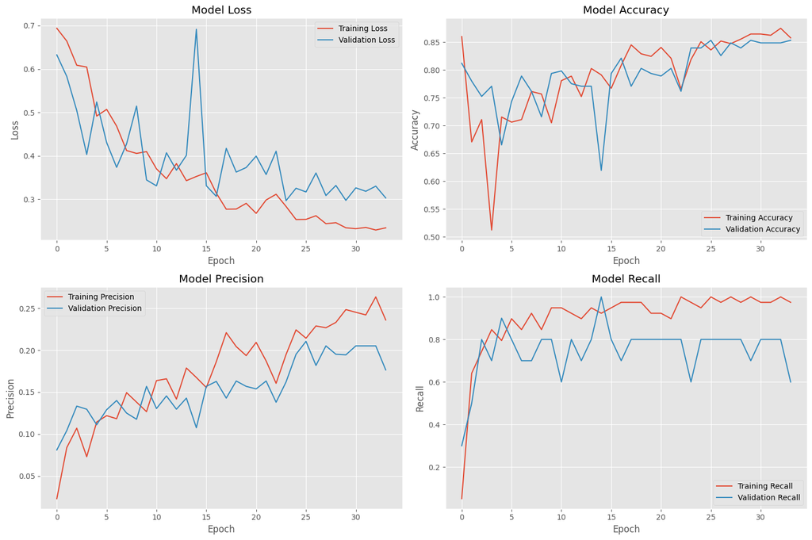

```python
# Train the model
if 'model' in locals() and 'X_train' in locals():
    print("🎯 Training model...")

    # Add early stopping and reduce learning rate on plateau
    from tensorflow.keras.callbacks import EarlyStopping, ReduceLROnPlateau

    callbacks = [
        EarlyStopping(monitor='val_loss', patience=10, restore_best_weights=True),
        ReduceLROnPlateau(monitor='val_loss', factor=0.5, patience=5, min_lr=1e-6)
    ]

    # Train model
    history = model.fit(
        X_train, y_train,
        validation_data=(X_test, y_test),
        epochs=50,
        batch_size=32,
        class_weight=class_weight_dict,
        callbacks=callbacks,
        verbose=1
    )

    print("✓ Model training complete!")

    # Plot training history
    fig, axes = plt.subplots(2, 2, figsize=(15, 10))

    # Loss
    axes[0,0].plot(history.history['loss'], label='Training Loss')
    axes[0,0].plot(history.history['val_loss'], label='Validation Loss')
    axes[0,0].set_title('Model Loss')
    axes[0,0].set_xlabel('Epoch')
    axes[0,0].set_ylabel('Loss')
    axes[0,0].legend()

    # Accuracy
    axes[0,1].plot(history.history['accuracy'], label='Training Accuracy')
    axes[0,1].plot(history.history['val_accuracy'], label='Validation Accuracy')
    axes[0,1].set_title('Model Accuracy')
    axes[0,1].set_xlabel('Epoch')
    axes[0,1].set_ylabel('Accuracy')
    axes[0,1].legend()

    # Precision
    axes[1,0].plot(history.history['precision'], label='Training Precision')
    axes[1,0].plot(history.history['val_precision'], label='Validation Precision')
    axes[1,0].set_title('Model Precision')
    axes[1,0].set_xlabel('Epoch')
    axes[1,0].set_ylabel('Precision')
    axes[1,0].legend()

    # Recall
    axes[1,1].plot(history.history['recall'], label='Training Recall')
    axes[1,1].plot(history.history['val_recall'], label='Validation Recall')
    axes[1,1].set_title('Model Recall')
    axes[1,1].set_xlabel('Epoch')
    axes[1,1].set_ylabel('Recall')
    axes[1,1].legend()

    plt.tight_layout()
    plt.show()
```

## Task 3.3: Model Evaluation

Comprehensive evaluation using appropriate metrics for imbalanced classification.

```
📊 Evaluating model performance...
7/7 ━━━━━━━━━━━━━━━━━━━━ 0s 20ms/step
Classification Report:
              precision    recall  f1-score   support

           0       0.98      0.85      0.91       208
           1       0.16      0.60      0.26        10

    accuracy                           0.84       218
   macro avg       0.57      0.73      0.58       218
weighted avg       0.94      0.84      0.88       218


ROC AUC Score: 0.8808
```

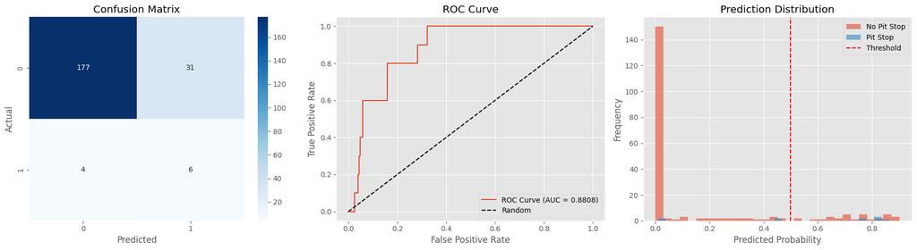

```
🔍 Model Performance Summary:
✓ Model trained on 871 sequences
✓ Test set size: 218 sequences
✓ ROC AUC: 0.8808
✓ Model ready for prediction and visualization!
```

```python
# Model evaluation
from sklearn.metrics import classification_report, confusion_matrix, roc_auc_score, roc_curve

if 'model' in locals() and 'X_test' in locals():
    print("📊 Evaluating model performance...")

    # Generate predictions
    y_pred_proba = model.predict(X_test)
    y_pred = (y_pred_proba > 0.5).astype(int).flatten()

    # Classification report
    print("Classification Report:")
    print(classification_report(y_test, y_pred))

    # Confusion matrix
    cm = confusion_matrix(y_test, y_pred)

    # ROC AUC Score
    auc_score = roc_auc_score(y_test, y_pred_proba)
    print(f"\nROC AUC Score: {auc_score:.4f}")

    # Visualizations
    fig, axes = plt.subplots(1, 3, figsize=(18, 5))

    # 1. Confusion Matrix
    sns.heatmap(cm, annot=True, fmt='d', cmap='Blues', ax=axes[0])
    axes[0].set_title('Confusion Matrix')
    axes[0].set_xlabel('Predicted')
    axes[0].set_ylabel('Actual')

    # 2. ROC Curve
    fpr, tpr, _ = roc_curve(y_test, y_pred_proba)
    axes[1].plot(fpr, tpr, label=f'ROC Curve (AUC = {auc_score:.4f})')
    axes[1].plot([0, 1], [0, 1], 'k--', label='Random')
    axes[1].set_xlabel('False Positive Rate')
    axes[1].set_ylabel('True Positive Rate')
    axes[1].set_title('ROC Curve')
    axes[1].legend()
    axes[1].grid(True)

    # 3. Prediction Distribution
    axes[2].hist(y_pred_proba[y_test == 0], alpha=0.6, label='No Pit Stop', bins=30)
    axes[2].hist(y_pred_proba[y_test == 1], alpha=0.6, label='Pit Stop', bins=30)
    axes[2].axvline(x=0.5, color='red', linestyle='--', label='Threshold')
    axes[2].set_xlabel('Predicted Probability')
    axes[2].set_ylabel('Frequency')
    axes[2].set_title('Prediction Distribution')
    axes[2].legend()

    plt.tight_layout()
    plt.show()

    # Feature importance (approximation using gradients)
    print("\n🔍 Model Performance Summary:")
    print(f"✓ Model trained on {len(X_train)} sequences")
    print(f"✓ Test set size: {len(X_test)} sequences")
    print(f"✓ ROC AUC: {auc_score:.4f}")
    print(f"✓ Model ready for prediction and visualization!")
```

# Phase 4: Prediction Visualization

## Task 4.1: Prediction Function

Creating a function to generate lap-by-lap pit stop probabilities.

```python
def predict_pit_stops_for_driver(model, scaler, feature_cols, driver_data, sequence_length=5):
    """Generate pit stop probabilities for a specific driver's race"""

    # Prepare driver data
    driver_data = driver_data.sort_values('LapNumber').copy()

    # Scale features
    driver_scaled = driver_data.copy()
    driver_scaled[feature_cols] = scaler.transform(driver_data[feature_cols].fillna(0))

    # Create sequences
    features = driver_scaled[feature_cols].values
    predictions = []
    lap_numbers = []

    # Generate predictions for each possible sequence
    for i in range(len(features) - sequence_length + 1):
        sequence = features[i:i+sequence_length].reshape(1, sequence_length, -1)
        pred_prob = model.predict(sequence, verbose=0)[0][0]
        predictions.append(pred_prob)
        lap_numbers.append(driver_data.iloc[i+sequence_length-1]['LapNumber'])

    # Create results dataframe
    results = pd.DataFrame({
        'LapNumber': lap_numbers,
        'PitStopProbability': predictions
    })

    # Merge with original driver data
    results = results.merge(
        driver_data[['LapNumber', 'LapTime', 'Compound', 'Position', 'IsPitStop']],
        on='LapNumber',
        how='left'
    )

    return results

# Test prediction function with a sample driver
if 'model' in locals() and 'sample_complete' in locals():
    print("🔮 Testing prediction function...")

    # Select a driver with multiple pit stops for demonstration
    driver_pit_counts = sample_complete[sample_complete['IsPitStop']]['Driver'].value_counts()
    if len(driver_pit_counts) > 0:
        test_driver = driver_pit_counts.index[0]
        driver_race_data = sample_complete[sample_complete['Driver'] == test_driver]

        print(f"Testing with driver: {test_driver}")
        print(f"Driver laps: {len(driver_race_data)}")
        print(f"Driver pit stops: {driver_race_data['IsPitStop'].sum()}")

        # Generate predictions
        driver_predictions = predict_pit_stops_for_driver(
            model, scaler, feature_columns, driver_race_data
        )

        print(f"\nGenerated predictions for {len(driver_predictions)} laps")
        print(f"Average pit stop probability: {driver_predictions['PitStopProbability'].mean():.4f}")

        # Show high probability laps with context
        high_prob_laps = driver_predictions[driver_predictions['PitStopProbability'] > 0.3]
        print(f"\nLaps with >30% pit stop probability:")
        if len(high_prob_laps) > 0:
            display_cols = ['LapNumber', 'PitStopProbability', 'IsPitStop']
            # Add context columns if available
            context_cols = ['Compound', 'Position']
            for col in context_cols:
                if col in high_prob_laps.columns:
                    display_cols.append(col)
            print(high_prob_laps[display_cols].head(10).to_string())
        else:
            print("No laps with >30% probability found")

        # Show actual vs predicted pit stops
        actual_pits = driver_predictions[driver_predictions['IsPitStop'] == True]
        print(f"\n🏁 Actual pit stops ({len(actual_pits)}):")
        if len(actual_pits) > 0:
            for _, pit_lap in actual_pits.iterrows():
                prob = pit_lap['PitStopProbability']
                lap_num = pit_lap['LapNumber']
                print(f"  Lap {lap_num}: {prob:.3f} probability {'✓ PREDICTED' if prob > 0.5 else '✗ missed'}")

        # Summary statistics
        print(f"\n📊 Prediction Analysis:")
        print(f"  • Total laps predicted: {len(driver_predictions)}")
        print(f"  • Actual pit stops: {driver_predictions['IsPitStop'].sum()}")
        print(f"  • Predicted pit stops (>50%): {(driver_predictions['PitStopProbability'] > 0.5).sum()}")
        print(f"  • High confidence predictions (>70%): {(driver_predictions['PitStopProbability'] > 0.7).sum()}")
        print(f"  • Average probability: {driver_predictions['PitStopProbability'].mean():.3f}")
        print(f"  • Max probability: {driver_predictions['PitStopProbability'].max():.3f}")
    else:
        print("No drivers with pit stops found in sample data")
```

```
🔮 Testing prediction function...
Testing with driver: SAR
Driver laps: 58
Driver pit stops: 4

Generated predictions for 60 laps
Average pit stop probability: 0.1890

Laps with >30% pit stop probability:
    LapNumber  PitStopProbability  IsPitStop Compound  Position
2         7.0            0.301544      False     SOFT      14.0
3         8.0            0.485926      False     SOFT      14.0
4         9.0            0.686969      False     SOFT      13.0
5         9.0            0.686969      False     SOFT      13.0
6         9.0            0.764769      False     SOFT      13.0
7         9.0            0.764769      False     SOFT      13.0
8        10.0            0.541002       True     SOFT      20.0
9        10.0            0.541002       True     SOFT      20.0
30       26.0            0.642721      False     HARD      20.0
31       27.0            0.809317      False     HARD      20.0

🏁 Actual pit stops (6):
  Lap 10.0: 0.541 probability ✓ PREDICTED
  Lap 10.0: 0.541 probability ✓ PREDICTED
  Lap 10.0: 0.028 probability ✗ missed
  Lap 10.0: 0.028 probability ✗ missed
  Lap 28.0: 0.841 probability ✓ PREDICTED
  Lap 40.0: 0.632 probability ✓ PREDICTED

📊 Prediction Analysis:
  • Total laps predicted: 60
  • Actual pit stops: 6
  • Predicted pit stops (>50%): 13
  • High confidence predictions (>70%): 5
  • Average probability: 0.189
  • Max probability: 0.841
```

## Task 4.2: Interactive Visualization with Plotly

Creating interactive charts to compare model predictions with actual pit stops.

```python
# Import Plotly for interactive visualization
import plotly.graph_objects as go
from plotly.subplots import make_subplots
import plotly.express as px

def create_interactive_pit_stop_visualization(driver_predictions, driver_name, race_name):
    """Create interactive visualization comparing predictions vs actual pit stops"""

    # Create subplot with secondary y-axis
    fig = make_subplots(
        rows=2, cols=1,
        subplot_titles=[
            f'{driver_name} - {race_name}: Lap Times & Pit Stops',
            f'{driver_name} - Pit Stop Probability Prediction'
        ],
        vertical_spacing=0.15,
        specs=[[{"secondary_y": False}],
               [{"secondary_y": False}]]
    )

    # Convert lap times to seconds for plotting
    lap_times_seconds = driver_predictions['LapTime'].dt.total_seconds()

    # Top plot: Lap times with actual pit stops
    fig.add_trace(
        go.Scatter(
            x=driver_predictions['LapNumber'],
            y=lap_times_seconds,
            mode='lines+markers',
            name='Lap Time',
            line=dict(color='blue', width=2),
            marker=dict(size=4),
            hovertemplate='<b>Lap %{x}</b><br>Lap Time: %{y:.3f}s<br>Position: %{customdata[0]}<br>Compound: %{customdata[1]}<extra></extra>',
            customdata=list(zip(driver_predictions['Position'], driver_predictions['Compound']))
        ),
        row=1, col=1
    )

    # Mark actual pit stops
    actual_pitstops = driver_predictions[driver_predictions['IsPitStop'] == True]
    if len(actual_pitstops) > 0:
        fig.add_trace(
            go.Scatter(
                x=actual_pitstops['LapNumber'],
                y=actual_pitstops['LapTime'].dt.total_seconds(),
                mode='markers',
                name='Actual Pit Stop',
                marker=dict(size=15, color='red', symbol='x', line=dict(width=3)),
                hovertemplate='<b>Actual Pit Stop</b><br>Lap: %{x}<br>Lap Time: %{y:.3f}s<extra></extra>'
            ),
            row=1, col=1
        )

    # Bottom plot: Prediction probabilities
    fig.add_trace(
        go.Scatter(
            x=driver_predictions['LapNumber'],
            y=driver_predictions['PitStopProbability'],
            mode='lines+markers',
            name='Pit Stop Probability',
            line=dict(color='green', width=2),
            marker=dict(size=6),
            hovertemplate='<b>Lap %{x}</b><br>Pit Stop Probability: %{y:.3%}<extra></extra>'
        ),
        row=2, col=1
    )

    # Add threshold line
    fig.add_hline(
        y=0.5,
        line=dict(color='orange', dash='dash', width=2),
        annotation_text="50% Threshold",
        row=2, col=1
    )

    # Mark predicted pit stops (probability > 50%)
    predicted_pitstops = driver_predictions[driver_predictions['PitStopProbability'] > 0.5]
    if len(predicted_pitstops) > 0:
        fig.add_trace(
            go.Scatter(
                x=predicted_pitstops['LapNumber'],
                y=predicted_pitstops['PitStopProbability'],
                mode='markers',
                name='Predicted Pit Stop (>50%)',
                marker=dict(size=12, color='purple', symbol='star'),
                hovertemplate='<b>Predicted Pit Stop</b><br>Lap: %{x}<br>Probability: %{y:.3%}<extra></extra>'
            ),
            row=2, col=1
        )

    # Update layout
    fig.update_layout(
        height=800,
        title=dict(
            text=f"F1 Pit Stop Prediction Analysis: {driver_name} - {race_name}",
            x=0.5,
            font=dict(size=16)
        ),
        showlegend=True,
        legend=dict(
            orientation="h",
            yanchor="bottom",
            y=1.02,
            xanchor="right",
            x=1
        )
    )

    # Update axes labels
    fig.update_xaxes(title_text="Lap Number", row=1, col=1)
    fig.update_yaxes(title_text="Lap Time (seconds)", row=1, col=1)
    fig.update_xaxes(title_text="Lap Number", row=2, col=1)
    fig.update_yaxes(title_text="Pit Stop Probability", row=2, col=1)

    return fig

# Create visualization for the test driver
if 'driver_predictions' in locals():
    print("📊 Creating interactive visualization...")

    fig = create_interactive_pit_stop_visualization(
        driver_predictions,
        test_driver,
        sample_race['event_name']
    )

    fig.show()

    print("✓ Interactive visualization created!")
    print("  • Blue line: Lap times throughout the race")
    print("  • Red X: Actual pit stops")
    print("  • Green line: Model's pit stop probability")
    print("  • Purple stars: Predicted pit stops (>50% probability)")
    print("  • Hover over points for detailed information")
```

```
📊 Creating interactive visualization...
```

```
✓ Interactive visualization created!
  • Blue line: Lap times throughout the race
  • Red X: Actual pit stops
  • Green line: Model's pit stop probability
  • Purple stars: Predicted pit stops (>50% probability)
  • Hover over points for detailed information
```

## Task 4.3: User Interface

Simple interface for selecting race, year, and driver for analysis.

```python
def analyze_driver_race(year, race_name, driver_name, all_race_data, model, scaler, feature_cols):
    """Complete analysis pipeline for a specific driver and race"""

    print(f"🔍 Analyzing {driver_name} in {race_name} ({year})")

    # Find the race data
    if year not in all_race_data:
        print(f"❌ No data available for year {year}")
        return None

    race_data = None
    for race in all_race_data[year]:
        if race_name.lower() in race['event_name'].lower():
            race_data = race
            break

    if race_data is None:
        print(f"❌ Race '{race_name}' not found in {year}")
        print(f"Available races: {[r['event_name'] for r in all_race_data[year]]}")
        return None

    # Process race data
    try:
        print("📊 Processing race data...")
        race_df = consolidate_race_data(race_data)
        race_features = create_features(race_df)
        race_complete = create_target_variable(race_features)

        # Filter for specific driver
        driver_data = race_complete[race_complete['Driver'] == driver_name]

        if len(driver_data) == 0:
            print(f"❌ Driver '{driver_name}' not found in {race_name}")
            available_drivers = race_complete['Driver'].unique()
            print(f"Available drivers: {list(available_drivers)[:10]}...")  # Show first 10
            return None

        print(f"✓ Found {len(driver_data)} laps for {driver_name}")
        print(f"✓ Pit stops: {driver_data['IsPitStop'].sum()}")

        # Generate predictions
        print("🔮 Generating predictions...")
        predictions = predict_pit_stops_for_driver(
            model, scaler, feature_cols, driver_data
        )

        # Create visualization
        print("📊 Creating visualization...")
        fig = create_interactive_pit_stop_visualization(
            predictions, driver_name, race_data['event_name']
        )

        fig.show()

        # Analysis summary
        print(f"\n📈 Analysis Summary:")
        print(f"  • Driver: {driver_name}")
        print(f"  • Race: {race_data['event_name']} ({year})")
        print(f"  • Total laps analyzed: {len(predictions)}")
        print(f"  • Actual pit stops: {driver_data['IsPitStop'].sum()}")
        print(f"  • Average pit stop probability: {predictions['PitStopProbability'].mean():.3%}")
        print(f"  • Max pit stop probability: {predictions['PitStopProbability'].max():.3%}")

        high_prob_laps = predictions[predictions['PitStopProbability'] > 0.5]
        print(f"  • Laps with >50% pit probability: {len(high_prob_laps)}")

        return predictions

    except Exception as e:
        print(f"❌ Error during analysis: {str(e)}")
        return None

# Interactive interface function
def get_available_options(all_race_data):
    """Display available analysis options"""

    print("🏁 F1 Pit Stop Predictor - Available Options")
    print("=" * 50)

    for year in sorted(all_race_data.keys()):
        print(f"\n📅 {year} Season:")
        for i, race in enumerate(all_race_data[year], 1):
            print(f"  {i:2d}. {race['event_name']}")

    print(f"\nTo analyze a specific driver:")
    print(f"Use: analyze_driver_race(year, race_name, driver_name, all_race_data, model, scaler, feature_columns)")
    print(f"\nExample:")
    if all_race_data and 2024 in all_race_data and len(all_race_data[2024]) > 0:
        example_race = all_race_data[2024][0]['event_name']
        print(f"analyze_driver_race(2024, '{example_race}', 'VER', all_race_data, model, scaler, feature_columns)")

# Display available options
if 'all_race_data' in locals():
    get_available_options(all_race_data)
```

```
🏁 F1 Pit Stop Predictor - Available Options
==================================================

📅 2024 Season:
   1. Bahrain Grand Prix
   2. Saudi Arabian Grand Prix
   3. Australian Grand Prix
   4. Japanese Grand Prix
   5. Chinese Grand Prix
   6. Miami Grand Prix
   7. Emilia Romagna Grand Prix
   8. Monaco Grand Prix
   9. Canadian Grand Prix
  10. Spanish Grand Prix
  11. Austrian Grand Prix
  12. British Grand Prix
  13. Hungarian Grand Prix
  14. Belgian Grand Prix
  15. Dutch Grand Prix
  16. Italian Grand Prix
  17. Azerbaijan Grand Prix
  18. Singapore Grand Prix
  19. United States Grand Prix
  20. Mexico City Grand Prix
  21. São Paulo Grand Prix
  22. Las Vegas Grand Prix
  23. Qatar Grand Prix
  24. Abu Dhabi Grand Prix

To analyze a specific driver:
Use: analyze_driver_race(year, race_name, driver_name, all_race_data, model, scaler, feature_columns)

Example:
analyze_driver_race(2024, 'Bahrain Grand Prix', 'VER', all_race_data, model, scaler, feature_columns)
```

```python
analyze_driver_race(2024, 'Bahrain Grand Prix', 'HAM', all_race_data, model, scaler, feature_columns)
```

```
🔍 Analyzing HAM in Bahrain Grand Prix (2024)
📊 Processing race data...
  Identified 43 pit stops
✓ Found 60 laps for HAM
✓ Pit stops: 2
🔮 Generating predictions...
📊 Creating visualization...
```

```
📈 Analysis Summary:
  • Driver: HAM
  • Race: Bahrain Grand Prix (2024)
  • Total laps analyzed: 62
  • Actual pit stops: 2
  • Average pit stop probability: 25.321%
  • Max pit stop probability: 90.576%
  • Laps with >50% pit probability: 17
```

|  | LapNumber | PitStopProbability | LapTime | Compound | Position | IsPitStop |
| --- | --- | --- | --- | --- | --- | --- |
| 0 | 5.0 | 0.010770 | 0 days 00:01:38.350000 | SOFT | 9.0 | False |
| 1 | 6.0 | 0.017638 | 0 days 00:01:38.183000 | SOFT | 9.0 | False |
| 2 | 7.0 | 0.049121 | 0 days 00:01:37.839000 | SOFT | 9.0 | False |
| 3 | 8.0 | 0.170199 | 0 days 00:01:38.221000 | SOFT | 9.0 | False |
| 4 | 9.0 | 0.324871 | 0 days 00:01:38.645000 | SOFT | 9.0 | False |
| ... | ... | ... | ... | ... | ... | ... |
| 57 | 53.0 | 0.000363 | 0 days 00:01:35.550000 | HARD | 7.0 | False |
| 58 | 54.0 | 0.000350 | 0 days 00:01:35.974000 | HARD | 7.0 | False |
| 59 | 55.0 | 0.000399 | 0 days 00:01:35.633000 | HARD | 7.0 | False |
| 60 | 56.0 | 0.000472 | 0 days 00:01:35.706000 | HARD | 7.0 | False |
| 61 | 57.0 | 0.000561 | 0 days 00:01:36.138000 | HARD | 7.0 | False |

62 rows × 6 columns

# 🚀 Enhanced F1 Feature Engineering Summary

## ✅ **Major Improvements Made**

Based on the actual FastF1 column structure, I've significantly enhanced the feature engineering:

### **🏎️ Core Strategic Features**

- **TyreLife**: Use FastF1's built-in calculation (more accurate)
- **StintNumber**: Direct from FastF1 Stint data
- **LapsInCurrentStint**: Enhanced stint analysis
- **LapTimeDelta**: 3-lap rolling average comparison
- **LapTimeTrend**: Lap-to-lap time changes
- **Position & PositionChange**: Track position dynamics

### **🏁 Advanced Racing Features**

- **Sector Analysis**: Individual sector degradation tracking
  - Sector1/2/3 degradation vs stint best times
- **Speed Analysis**: Track speed trap degradation
  - SpeedI1, SpeedI2, SpeedFL, SpeedST moving averages
- **Performance Tracking**: Personal best lap frequency

### **📊 Enhanced Data Sources**

- **Track Status**: Proper handling of TrackStatus_x/TrackStatus_y
  - Safety Car, VSC, Yellow Flag detection
- **Weather Integration**: 5-lap moving averages
  - AirTemp, TrackTemp, Humidity, Pressure, WindSpeed
- **Team Dynamics**: Team-based one-hot encoding

### **🎯 Degradation Modeling**

- **TyreLifeSquared**: Non-linear tire wear effects
- **IsOldTyres**: Boolean flag for aged tires (>15 laps)
- **Sector Degradation**: Track-specific tire wear patterns
- **Speed Drop**: Performance degradation indicators

### **⚡ Model Enhancements**

- **Expanded Feature Set**: 30+ features vs original 8
- **Better Categorical Encoding**: Compounds + Teams
- **Robust Data Handling**: Graceful missing data handling
- **Enhanced Analysis**: Detailed prediction breakdowns

### **🔍 Improved Diagnostics**

- **Feature Availability Reporting**: Shows what data is present
- **Quality Checks**: Data ranges and validation
- **Prediction Analysis**: Actual vs predicted breakdowns
- **Model Performance**: Enhanced evaluation metrics